# Análisis de expresión génica y funcional de la Electroacupuntura en *Rattus Norvegicus*

Jessica Garcia, Manuel Rivera, Axel Rodriguez

2023-03-03

# 1 Abstract

La electroacupuntura (EA) ha surgido como una posible estrategia no invasiva para mejorar la permeabilidad de la barrera hematoencefálica (BBB) y facilitar la administración de fármacos al sistema nervioso central (SNC). Sin embargo, los mecanismos moleculares subyacentes a esta respuesta aún no se comprenden completamente. En ese estudio, se llevó a cabo un análisis bioinformático de los datos de secuenciación de ARN (RNA-Seq) de un experimento previo que evaluó los cambios en la expresión génica en la corteza cerebral de ratas sometidas a EA.

Nosotros como equipo realizamos un análisis bioinformático que incluirá el control de calidad de las secuencias crudas, la curación de los datos utilizando Trimmomatic, el alineamiento de las secuencias limpias con Kallisto, el análisis diferencial de expresión génica utilizando DESeq2 y el análisis funcional para determinar el enriquecimiento de genes en funciones biológicas específicas. De tal manera que podamos obtener resultados de genes significativamente diferencialmente expresados en el grupo de EA en comparación con el grupo de control.

# 2 Introducción

La administración de fármacos al sistema nervioso central (SNC) representa un desafío debido a la presencia de la barrera hematoencefálica (BBB), la cual limita el paso de moléculas terapéuticas desde la circulación sistémica al cerebro. En los últimos años, se ha investigado el uso de la electroacupuntura (EA) como una estrategia no invasiva para mejorar la permeabilidad de la BBB y facilitar la entrega de fármacos al cerebro. Sin embargo, los mecanismos moleculares subyacentes a esta respuesta no se comprenden completamente.

El artículo previo utilizó la secuenciación de ARN (RNA-Seq) y análisis bioinformáticos para identificar los genes diferencialmente expresados en la corteza cerebral de ratas sometidas a EA en comparación con el grupo de control. Estos genes podrían desempeñar un papel crucial en la modulación de la permeabilidad de la BBB y, por lo tanto, son candidatos prometedores para futuras investigaciones y terapias.

Nuestro enfoque de análisis bioinformático comprenderá varias etapas, que incluyen el análisis de calidad de las secuencias crudas, la limpieza de adaptadores, el alineamiento de las secuencias limpias, el análisis diferencial de expresión génica y el análisis funcional para determinar el enriquecimiento de genes en funciones biológicas específicas. Estos pasos nos permitirán comparar nuestros resultados con los resultados del artículo en donde observaron los cambios en la expresión génica inducidos por la EA y su relevancia en la permeabilidad de la BBB.

# 3 Métodos

## 3.1 Descargar los SRA

```bash
# generar una carpeta en el cluster para trabajar
mkdir RNASeq
# crear un carpeta para descagar los SRA
mkdir data
# crear txt con los SRA  a descargar
nano mice_fastq.txt
# crear el job de descargar de los SRA
nano SRAData_dow.sge
# mandar el job a descargar
qsub SRAData_dow.sge
# observar el estado del job
qstat
```

Contenido de mice_fastq.txt

```bash
SRR17400880
SRR17400881
SRR17400882
SRR17400887
SRR17400883
SRR17400886
SRR17400884
SRR17400885
SRR17400888
SRR17400889
```

Contenido del job:

```bash
#!/bin/bash
#
# Use Current working directory
#$ -cwd
#
# Join stdout and stderr
#$ -j n
#
# Run job through bash shell
#$ -S /bin/bash
#
# You can edit the script since this line
#
# Your job name
#$ -N SRAData_dow
#
# Send an email after the job has finished
#$ -m e
#$ -M jessgarrrcia@gmail.com
#
#
# If modules are needed, source modules environment (Do not delete the next line):
. /etc/profile.d/modules.sh
#
# Add any modules you might require:
module load sra/3.0.0
#
# Write your commands in the next line

# Descarga de datos

# PARTE 1.- Descargar SRA
prefetch --option-file ./mice_fastq.txt -O ./data

# --option-file : archivo de entrada con cada SRA por renglon
# -O : salida

# PARTE 2.- Cambio de SRA a Fastq
fastq-dump --gzip --skip-technical --dumpbase --split-3 --clip --outdir ./data/ ./data/SRR*/*.sra

# --gzip : Descomprimir archivos comprimidos con .gz
# --skip-technical : Optener solo lecturas de cada replica biologica. No tecnicas.
# --dumpbase : Formato de las secuencias basada en espacios.
# --split-3 : Separar archivos dependiendo del SRA en single-end con *.fastq, si es paired-end con *_1.fastq y *_2.fastq
# --clip : Remover adaptadores de las lecturas
# --outdir : salida
```

## 3.2 Análisis de calidad de secuencias (FastQC y multiQC) de los datos crudos

Crearemos una carpeta llamada FastQC_rawData en donde vamos a tener el análisis de calidad de los datos crudos.

```bash
# directorio de trabajo
cd /mnt/Timina/bioinfoII/jgarcia/RNASeq
# crear carpeta
mkdir FastQC_rawData
```

Posteriormente, vamos a iniciar el análisis de calidad de las lecturas crudas o sin procesar (raw data)

```bash
# cargar module FastQC
module load fastqc/0.11.3

# Crear fastqc por lectura
fastqc ./data/*.fastq.gz -o ./FastQC_rawData
```

`fastqc ./data/*.fastq.gz -o ./FastQC_rawData` indica que realice un fastqc a todos los archivos contenidos en la carpeta data que terminen con .fastq.gz y que los outputs los ponga en la carpeta FastQC_rawData.

Ahora bien, se utiliza la herramienta MultiQC, la cual crea un único informe con gráficos interactivos para múltiples análisis bioinformáticos en muchas muestras. Se corre el siguiente código.

```bash
# Cargar modulo
module load multiqc/1.5
# Generar reporte multiqc
multiqc ./FastQC_rawData -o ./FastQC_rawData
```

Para poder visualizar el informe multiqc, se descarga el archivo a nuestro ordenador con el siguiente comando:

```bash
rsync -rptuvl jgarcia@dna.lavis.unam.mx:/mnt/Timina/bioinfoII/jgarcia/RNASeq/FastQC_rawData/multiqc_report.html .
```

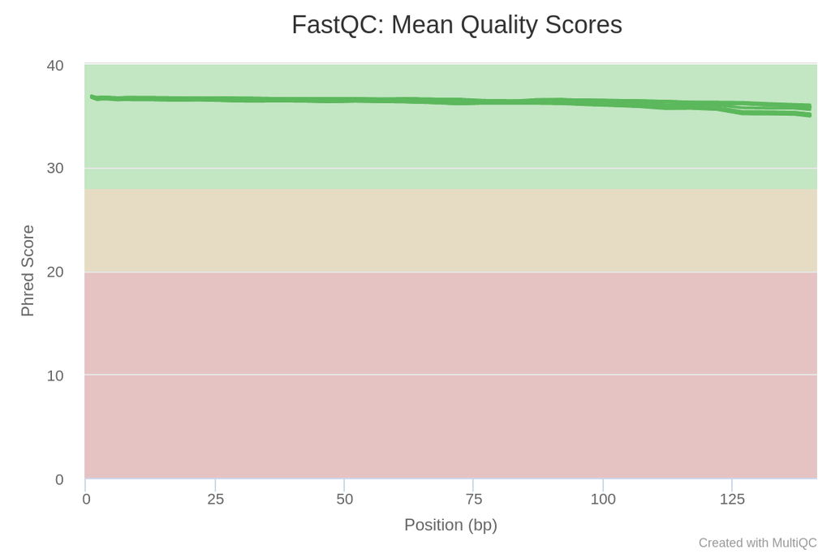

En esta gráfica podemos observar que el valor medio de calidad en cada posición de base de la lectura es bastante bueno para cada una de las muestras.

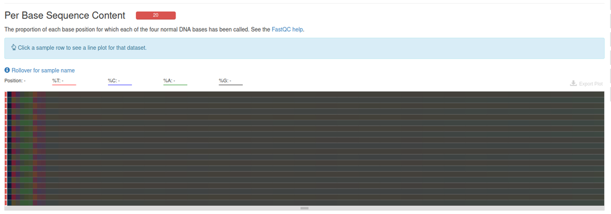

Este heatmap nos muestra que la proporción de cada posición de base para la que se ha llamado a cada una de las cuatro bases normales del ADN en cada una de las muestras no pasó el filtro. Hay niveles demasiado bajos.

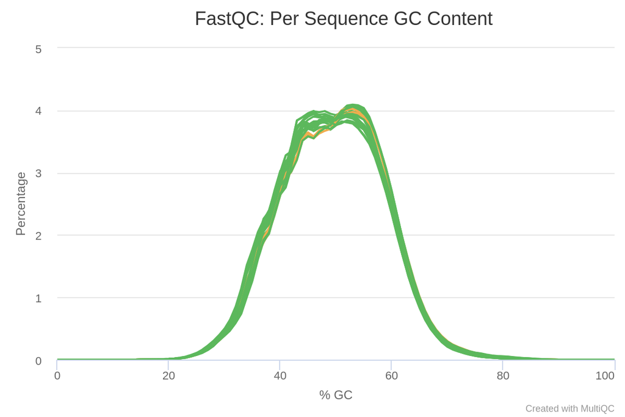

Esta imagen nos releva el contenido medio de GC de las lecturas y este se observa bastante bien para la mayoría de las muestras (17) para un par de ellas se ven comprometidas (3).

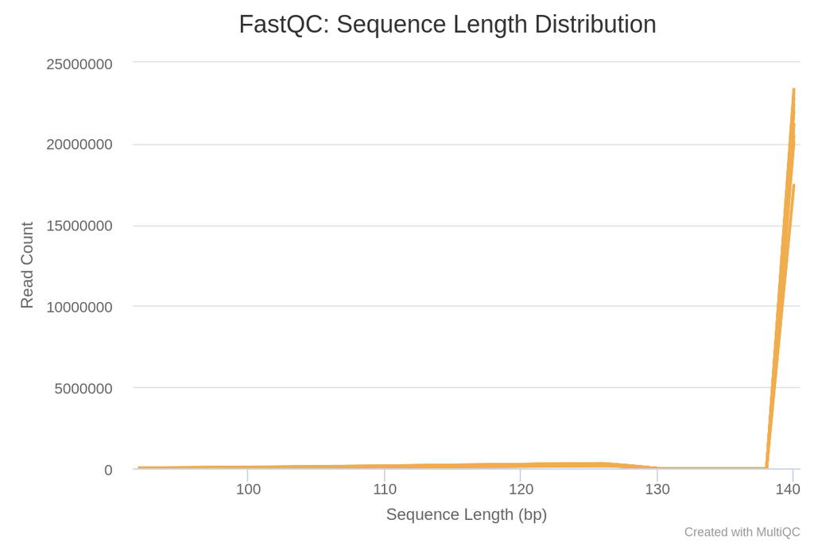

En esta imagen podemos observar que las 20 muestras se ven comprometidas en la distribución de tamaños de fragmentos (longitudes de lectura) encontrados.

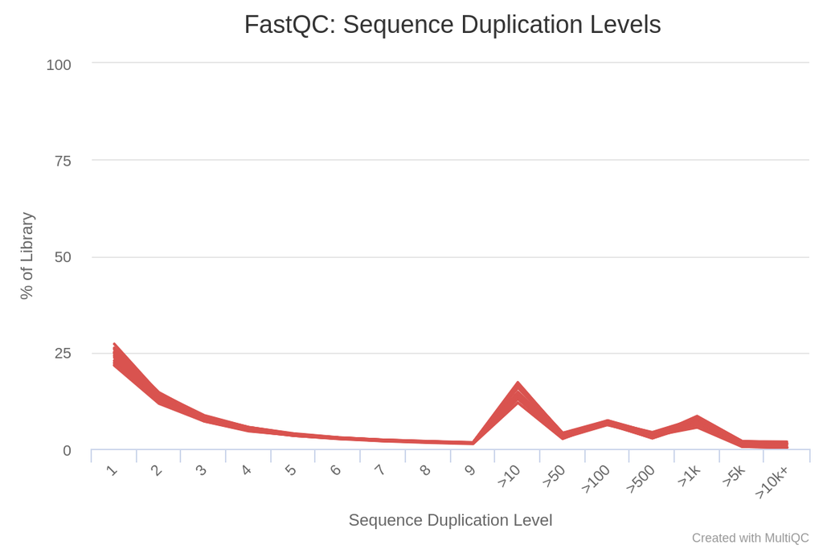

En esta última imagen podemos observar el nivel relativo de duplicación encontrado para cada secuencia. Todas las muestras se encuentran en niveles extremedamente bajos.

Tras el análisis de calidad de secuencias crudas, optamos por curar los datos con Trimmomatic para mejorar los niveles bajos obtenidos en distintas gráficas.

## 3.3 Limpieza de adaptadores

Para la limpieza de adaptadores primeramente creamos una carpeta llamada data_trimmed en donde vamos a almacenar las secuencias limpias que, mediante un job llamado Trimmed_run.sge vamos a generar un análisis de datos y posteriormente reedirigirlo a una carpeta llamada FastQC_trimmed.

```bash
mkdir data_trimmed
mkdir FastQC_trimmed
nano Trimmed_run.sge
```

Contenido del job Trimmed_run.sge

```bash
#!/bin/bash
#
# Use Current working directory
#$ -cwd
#
# Join stdout and stderr
#$ -j n
#
# Run job through bash shell
#$ -S /bin/bash
#
# You can edit the script since this line
#
# Your job name
#$ -N Trimmed_run
#
# Send an email after the job has finished
#$ -m e
#$ -M jessgarrrcia@gmail.com
#
#
# If modules are needed, source modules environment (Do not delete the next line):
. /etc/profile.d/modules.sh
#
# Add any modules you might require:
module load fastqc/0.11.3
module load multiqc/1.5
module load trimmomatic/0.33
#
# PARTE 1.- FastQC y multiQC
fastqc ./data/*.fastq.gz -o ./FastQC_rawData
multiqc ./FastQC_rawData -o ./FastQC_rawData

# PARTE 2.- Limpieza de adaptadores
# paired-end
cd data
for i in *_1.fastq.gz;
do echo
trimmomatic PE -threads 8 -phred33 $i "${i%_1.fastq.gz}_2.fastq.gz" \
../data_trimmed/"${i%_1.fastq.gz}_1_trimmed.fastq.gz" ../data_trimmed/"${i%_1.fastq.gz}_1_unpaired.fastq.gz" \
../data_trimmed/"${i%_1.fastq.gz}_2_trimmed.fastq.gz" ../data_trimmed/"${i%_1.fastq.gz}_2_unpaired.fastq.gz" \
ILLUMINACLIP:../TruSeq3-PE.fa:2:30:10 LEADING:3 TRAILING:3 SLIDINGWINDOW:5:20 MINLEN:60
done

# PARTE 3.- FastQC y multiQC
cd ../
fastqc ./data_trimmed/*.fastq.gz -o ./FastQC_trimmed
# Reporte en MultiQC
multiqc ./FastQC_trimmed -o ./FastQC_trimmed
```

Trimmomatic es la herramienta de línea de comandos rápida que utilizamos para recortar y curar datos de Illumina (FASTQ), así como para eliminar adaptadores.

## 3.4 Análisis de calidad de secuencias (FastQC y multiQC) de los datos limpios

Para analizar la calidad de secuencias descargamos el reporte multiqc a nuestro ordenador.

```bash
rsync -rptuvl jgarcia@dna.lavis.unam.mx:/mnt/Timina/bioinfoII/jgarcia/RNASeq/data/FastQC_trimmed/multiqc_report.html .
```

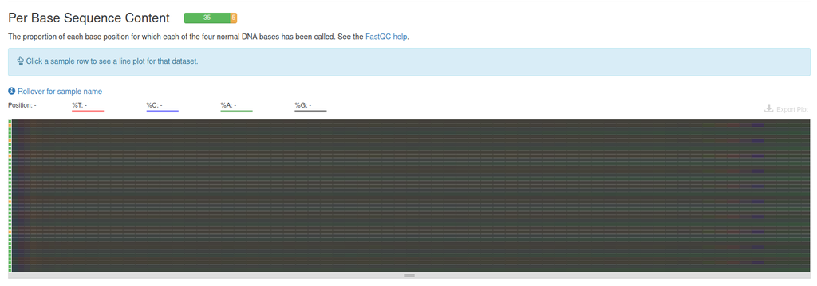

Este heatmap nos muestra que la proporción de cada posición de base para la que se ha llamado a cada una de las cuatro bases normales del ADN en cada una de las muestras mejoró bastante. Mucho más de la mitad de las muestras ahora pasa el filtro. Sin embargo, hay un par de muestras que aún muestras niveles deficientes.

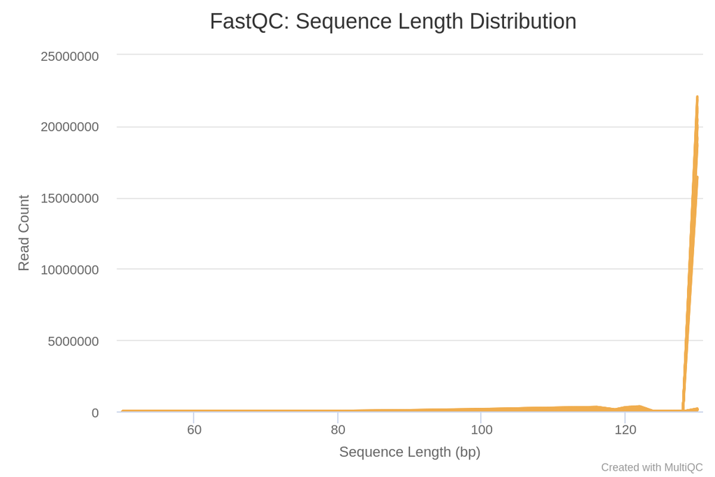

En esta imagen podemos observar que aún con el uso de Trimmomatic las muestras siguen mostrando los mismos valores en la distribución de tamaños de fragmentos (longitudes de lectura) encontrados.

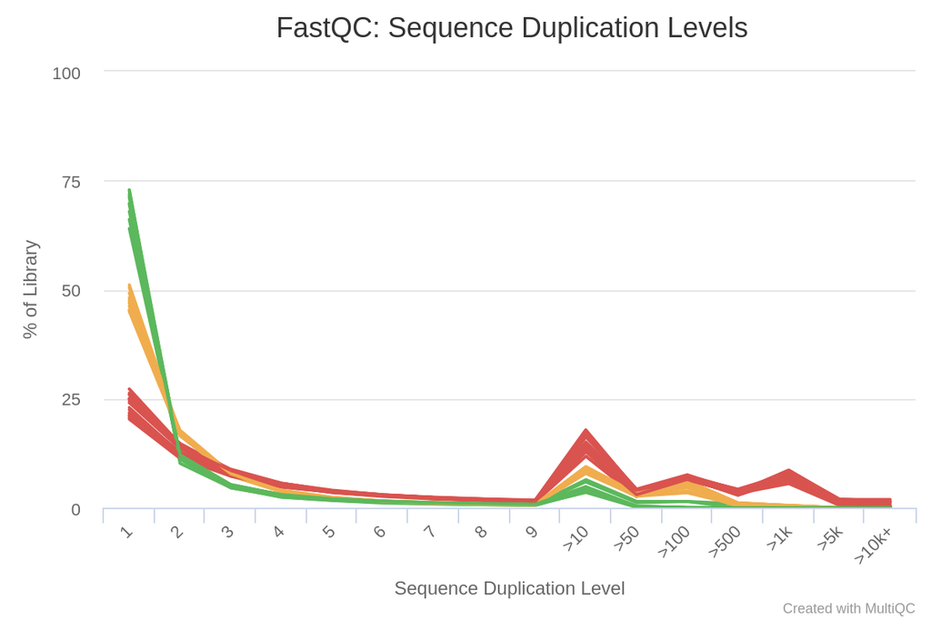

En esta última imagen podemos observar que el nivel relativo de duplicación encontrado para cada secuencia disminuyó en un par de muestras; posicionando a muchas de ellas en niveles adecuados y en niveles intermedios. Sin embargo, aún con la limpieza de datos, existen un par de muestras con niveles muy bajos.

El uso de Trimmomatic nos ayudó a reducir los datos en los que se presentaba algún tipo de problema de secuenciación. Todavía quedaron algunas muestras con algunas deficiencias, sin embargo, muchas de ellas se redujeron.

## 3.5 Programa de predicción de cuentas (Kallisto)

Continuando con los pasos del pipeline, haremos uso de Kallisto quant el cual es una herramienta de pseudoalineamiento para datos de transcriptoma la cual se basa en la probabilidad de asignación correcta de las lecturas a un transcrito.

Para ello, creamos una nueva carpeta llamada `kallisto_quant_test` y un job llamado `Kallisto_down_data.sge` que contiene las intrucciones para realizar el pseudoalineamiento con ayuda de un transcrito de referencia que obtuvimos con las siguientes líneas de código.

```bash
# Carpeta de archivos kallisto
mkdir kallisto_quant_test

# Para descargar transcriptoma de referencia realizamos lo siguiente:

# Generar transcriptoma de referencia mediante el JOB 'Transcript_down.sge', con las instrucciones:
wget https://ftp.ncbi.nlm.nih.gov/genomes/all/GCF/015/227/675/GCF_015227675.2_mRatBN7.2/GCF_015227675.2_mRatBN7.2_rna.fna.gz
# Creación del JOB para realizar el pseudoalineamiento
nano Kallisto_down_data.sge
```

Información que contiene el job Kallisto_down_data.sge

```bash
#!/bin/bash
#
# Use Current working directory
#$ -cwd
#
# Join stdout and stderr
#$ -j n
#
# Run job through bash shell
#$ -S /bin/bash
#
# You can edit the script since this line
#
# Your job name
#$ -N Rat_kallisto
#
# Send an email after the job has finished
#$ -m e
#$ -M axelrdz5205@gmail.com
#
#
# If modules are needed, source modules environment (Do not delete the next line):
. /etc/profile.d/modules.sh
#
# Add any modules you might require:
module load kallisto/0.45.0
#
# Write your commands in the next line

# Dentro de /mnt/Timina/bioinfoII/rnaseq/BioProject_2023/rawData/Homo_sapiens/data_trimmed

# Generar index de kallisto
kallisto index ./GCF_015227675.2_mRatBN7.2_rna.fna.gz -i ../kallisto_quant_test/mRat_ref.kidx

# - i nombre del archivo de salida, i.e., indice
#- Input = GCF_015227675.2_mRatBN7.2_rna.fna.gz, transcriptoma de referencia

 # Paired-end
for file in ./*_1_trimmed.fastq.gz                                                 # Read1
do
  clean=$(echo $file | sed 's/_trimmed//;s/\.fastq\.gz//;s/_1//')         # Nombre de la carpeta de salida, mismo nombre de SRA
  file_2=$(echo ${clean}_2_trimmed.fastq.gz| sed 's/FP/RP/')                                            # Read2
  kallisto quant --index ../kallisto_quant_test/mRat_ref.kidx --output-dir ../kallisto_quant_test/${clean} --threads 12 ${file} ${file_2}
done
```

Ahora bien, para asegurarnos que el pseudoalineamiento se realizó correctamente deberíamos tener los archivos tipo .h5, .tsv y json de cada muestra así que realizamos las siguientes líneas de código para verificar que efectivamente se encuentran esos archivos.

```bash
cd /mnt/Timina/bioinfoII/arodriguez/Repositorios/kallisto_quant_test
cd SRR18745762 #entrar a cada una de las muestras
ls
```

Observamos que en cada muestra hubo un buen alineamiento, así que procedemos a recuperar estos resultados descargando los datos a nuestro computador con la siguiente línea de comando

```bash
# Descagar resultados de kallisto
rsync -rptuvl jgarcia@dna.liigh.unam.mx:/mnt/Timina/bioinfoII/arodriguez/Repositorios/kallisto_quant_test/SRR* .
```

El siguiente paso que sigue el pipeline que estamos realizando es el análisis de expresión diferencial.

## 3.6 Expresión diferencial

El objetivo del análisis de expresión diferencial es realizar análisis estadísticos para tratar de descubrir cambios en los niveles de expresión de características definidas (genes, transcripciones, exones) entre grupos experimentales con muestras replicadas.

### 3.6.1 Instalaciones

Para realizar el análisis de expresión diferencial, se empleó el proyecto de R de Bioconductor, una plataforma que ofrece una variedad de paquetes y métodos diseñados específicamente para el análisis de datos omicos.

Los paquetes utilizados fueron `tximport_1.28.0`, cuya función es importar y resumir datos a nivel de transcripción generados a partir de herramientas de cuantificación; `tidyverse_2.0.0`, para hacer más fácil y eficiente la manipulación, visualización y análisis de datos; `DESeq2_1.40.1`, para identificar genes que se expresan diferencialmente entre dos o más condiciones experimentales; `ggplot2_3.4.2`, para crear varios tipos de gráficos; `ggrepel_0.9.3`, para crear etiquetas de texto que se ajustan automáticamente; `rhdf5_2.44.0`, que permite una lectura, escritura, manipulación y gestión eficientes de conjuntos de datos complejos; `GenomicFeatures_1.52.0`, que permite a los usuarios importar, consultar, recuperar y visualizar características genómicas; `biomaRt_2.56.0`, para acceder, recuperar, integrar y analizar datos biológicos de varias bases de datos; `pheatmap_1.0.12`, para crear mapas de calor personalizables y visualmente atractivos; y `genefilter_1.82.1`, para filtrar y seleccionar genes según diversos criterios en el análisis de datos genómicos de alto rendimiento.

```r
library(tximport)
library(tidyverse)
library(DESeq2)
library(ggplot2)
library(ggrepel)
library(rhdf5)
```

### 3.6.2 Importacion de datos de kallisto en R (*Import transcript-level estimates*)

Primero, creamos un vector apuntando a los archivos de cuantificación (los `abundance.h5`). Leyendo una tabla que contiene su respectivo SRR, y luego combinándolo con `"."` y `"abundance.h5"`, el vector tendrá los nombres de los archivos.

```r
# > R norvegicus
# generar tabla de metadatos
Rn_metadata.tsv <- data.frame("SRA" =c("SRR17400880",  # EA 5
                                       "SRR17400881", # EA 4
                                       "SRR17400882", # EA 3
                                       "SRR17400887", # EA 2
                                       "SRR17400883", # EA 1
                                       "SRR17400886", "SRR17400884", "SRR17400885", "SRR17400888", "SRR17400889"),  # Controles
                              "sample" = c("EA_5","EA_4", "EA_3", "EA_2",  "EA_1",
                                           "control_5", "control_4",  "control_3", "control_2", "control_1") ,
                              "dex" = c(rep("EA",5),
                                        rep("control",5)),
                              "species" = "Rattus norvegicus")
```

Entonces, generamos un código que carga metadatos desde un archivo, genera rutas de archivo para los archivos de abundancia, asigna nombres a las rutas y verifica si los archivos correspondientes existen.

```r
# Anotacion articulo
Rn_samples <- Rn_metadata.tsv
Rn_samples
```

```
##            SRA    sample     dex           species
## 1  SRR17400880      EA_5      EA Rattus norvegicus
## 2  SRR17400881      EA_4      EA Rattus norvegicus
## 3  SRR17400882      EA_3      EA Rattus norvegicus
## 4  SRR17400887      EA_2      EA Rattus norvegicus
## 5  SRR17400883      EA_1      EA Rattus norvegicus
## 6  SRR17400886 control_5 control Rattus norvegicus
## 7  SRR17400884 control_4 control Rattus norvegicus
## 8  SRR17400885 control_3 control Rattus norvegicus
## 9  SRR17400888 control_2 control Rattus norvegicus
## 10 SRR17400889 control_1 control Rattus norvegicus
```

```r
Rn_files   <- file.path("./Kallisto_quant", Rn_samples$SRA,"abundance.h5") # Crear ruta a cada archivo abundance de cada SRA
names(Rn_files) <- Rn_samples$SRA # Nombrar las rutas con el nombre de su correspondiente SRA
all(file.exists(Rn_files))
```

```
## [1] TRUE
```

La función `file.path` te permite crear una ruta a un archivo específico en un directorio de trabajo. En este caso, una ruta para cada archivo `abundance.tsv`. Las transcripciones deben asociarse con identificadores genéticos (*gene IDs*) para el resumen a nivel genético (*gene-level summarization*). Si esa información está presente en los archivos, podemos omitir este paso. Para Salmon, Sailfish, y kallisto los archivos sólo proporcionan el ID de la transcripción.

Primero hacemos un *data-frame* llamado `tx2gene` con dos columnas: 1) ID de la transcripción y 2) ID del gen. Los nombres de las columnas no importan, pero este orden de columnas debe ser utilizado. El ID de la transcripción debe ser el mismo utilizado en los archivos `abundance.tsv`.

```r
library(GenomicFeatures)
txdb <- makeTxDbFromGFF(file="Rattus_norvegicus.mRatBN7.2.109.gtf.gz") # Archivo de anotación de la rata
saveDb(x=txdb, file = "Rattus_norvegicus.mRatBN7.2.109.gtf.TxDb")
k <- keys(txdb, keytype = "TXNAME")
tx2gene <- select(txdb, k, "GENEID", "TXNAME")
write.table(tx2gene, "tx2gene.ensembl.mRatBN7.csv", sep = "\t", row.names = FALSE)
```

Luego, leemos en una tabla `tx2gene` (pre-construida), la cual vincula las transcripciones a los genes para este conjunto de datos:

```r
Rn_tx2gene   <- read.csv("tx2gene.ensembl.mRatBN7.csv", sep="\t",header=TRUE)
head(Rn_tx2gene)
```

```
##               TXNAME             GENEID
## 1 ENSRNOT00000109151 ENSRNOG00000065394
## 2 ENSRNOT00000096177 ENSRNOG00000070568
## 3 ENSRNOT00000099343 ENSRNOG00000066280
## 4 ENSRNOT00000109762 ENSRNOG00000063562
## 5 ENSRNOT00000106905 ENSRNOG00000063562
## 6 ENSRNOT00000117015 ENSRNOG00000065285
```

La función `read.csv` lee un archivo en formato tabla y crea un *data frame* a partir de el, con casos correspondientes a líneas y variables a campos del archivo.

Para la importación de los datos de cuantificación a nivel de transcripción necesarios para el análisis de expresión diferencial, se utilizó el paquete tximport. En este caso, el argumento type se utilizó para especificar que el software utilizado para la estimación fue kallisto. La función devuelve una lista con matrices que resumen la información del nivel de transcripción al nivel genético, incluyendo “abundance”, “counts” y “length”. La matriz `"length"` se puede utilizar para generar una matriz de desplazamiento para el análisis diferencial a nivel genético de matrices de conteo (*offset matrix for downstream gene-level differential analysis*), como se muestra abajo.

```r
Rn_txi_kallisto <- tximport(Rn_files, type = "kallisto", tx2gene=Rn_tx2gene, ignoreAfterBar=TRUE, txOut = TRUE)
```

```
## 1 2 3 4 5 6 7 8 9 10
```

```r
names(Rn_txi_kallisto)
```

```
## [1] "abundance"           "counts"              "length"
## [4] "countsFromAbundance"
```

```r
head(Rn_txi_kallisto$counts)
```

```
##                SRR17400880 SRR17400881 SRR17400882 SRR17400887 SRR17400883
## NM_001000000.1           0   0.0000000           0           0           0
## NM_001000001.1           0   3.0000000           0           0           2
## NM_001000002.1           0   1.0000000           0           0           2
## NM_001000003.1           0   0.3333333           0           0           0
## NM_001000004.1           0   0.0000000           0           0           0
## NM_001000005.1           0   0.0000000           0           0           0
##                SRR17400886 SRR17400884 SRR17400885 SRR17400888 SRR17400889
## NM_001000000.1           0           0           0           0           0
## NM_001000001.1           3           5           0           7           4
## NM_001000002.1           2           0           0           2           0
## NM_001000003.1           0           0           0           0           0
## NM_001000004.1           0           0           0           0           0
## NM_001000005.1           0           0           0           0           0
```

Note que añadimos un argumento adicional en este fragmento de código, `ignoreAfterBar=TRUE`. Esto se debe a que las transcripciones del código genético tienen nombres como “NM_001000000. 1|NM_001000002. 1|. . .”, aunque nuestra tabla tx2gene solo incluye el primer identificador “NM_”. Por lo tanto, queremos dividir los nombres de las filas de la matriz de cuantificación entrante en la primera barra “|”, y solo usar esto como identificador.

Se debe asegurar que los nombres de fila de la tabla `Rn_samples` se alineen con los nombres de columna de `Rn_txi_kallisto$counts`, si hay nombres de fila.

```r
# nombre de los transcriptomas
rownames(Rn_samples) <- Rn_samples$sample # Nombre de cada fila como nombre de la muestra
colnames(Rn_txi_kallisto$counts) <-rownames(Rn_samples) # Nombre de cada columna como nombre de cada muestra
head(rownames(Rn_samples))
```

```
## [1] "EA_5"      "EA_4"      "EA_3"      "EA_2"      "EA_1"      "control_5"
```

```r
head(colnames(Rn_txi_kallisto$counts))
```

```
## [1] "EA_5"      "EA_4"      "EA_3"      "EA_2"      "EA_1"      "control_5"
```

Posteriormente, para construir un *DESeqDataSet* (`Rn_ddsTxi_all`) -objeto utilizado para almacenar las *read counts* y las cantidades intermedias estimadas (*intermediate estimated quantities*) durante el análisis estadístico- a partir del objeto `Rn_txi_kallisto` y mostrar información en muestras.

```r
# Importacion de los datos convirtiendolos en un objeto que puede leer Deseq.
Rn_ddsTxi_all <- DESeqDataSetFromTximport(Rn_txi_kallisto, Rn_samples, design = ~ dex) # Create a DESeq object from the tximport data
```

```
## using counts and average transcript lengths from tximport
```

### 3.6.3 Prefiltrado

Si bien no es necesario prefiltrar genes de bajo conteo antes de ejecutar las funciones DESeq2, hay dos razones que hacen útil el prefiltrado: 1. al eliminar filas en las que hay muy pocas lecturas, reducimos el tamaño de la memoria del objeto de datos dds (`Rn_ddsTxi_all`), y aumentamos la velocidad de las funciones de transformación y _testing__ dentro de DESeq2. 2. También puede mejorar las visualizaciones, ya que las características sin información para la expresión diferencial no se trazan.

Aquí realizamos un pre-filtrado mínimo para mantener sólo las filas que tienen al menos 10 lecturas en total.

```r
# Prefiltrado, eliminacion de genes con bajas cuentas
keep <- rowSums(counts(Rn_ddsTxi_all)) >= 10 # Si en una fila solo hay 10 cuentas (mapeo 10 veces)
Rn_ddsTxi_all <- Rn_ddsTxi_all[keep,]
Rn_dds_all <- DESeq(Rn_ddsTxi_all) # run Differential expression analysis
```

Los pasos de análisis de expresión diferencial estándar están envueltos en una sola función, `DESeq`.

### 3.6.4 Cuentas normalizadas para graficas (rlog)

Muchos métodos estadísticos comunes para el análisis exploratorio de datos multidimensionales, como el análisis de agrupación y componentes principales (PCA), funcionan mejor para datos que generalmente tienen el mismo rango de varianza en diferentes rangos de los valores de la media.

DESeq2 ofrece dos transformaciones para datos de conteo que estabilizan la varianza a través de la media: la *transformación estabilizadora de varianza (VST)*, y la transformación *regularizada de logaritmos* o *rlog*.

En este caso, utilizaremos rlog. A pesar de que VST es mucho más rápido de computar y es menos sensible a los valores atípicos con conteos altos que el rlog, este último tiende a funcionar bien en conjuntos de datos pequeños ($n$ < 30).

```r
Rn_all_normalized <- rlog(Rn_dds_all, blind=FALSE) # result rld, vst
Rn_all_normalized_db <- as.data.frame(assay(Rn_all_normalized))
head(Rn_all_normalized_db)
```

```
##                        EA_5       EA_4        EA_3         EA_2         EA_1
## NM_001000001.1  1.157084865 1.20512315  1.15808209  1.156927451  1.189548756
## NM_001000039.1  1.580274913 1.53889816  1.57375578  1.629227358  1.553423093
## NM_001000040.1 -0.008021222 0.06416476  0.04970663  0.037767127 -0.007871739
## NM_001000121.1  2.979852048 3.04537613  2.96673482  3.038726355  3.071683570
## NM_001000130.1 -0.078855825 0.01776073 -0.07784693 -0.009699854 -0.028976031
## NM_001000189.1  1.115455657 0.99006590  0.99412047  1.020948566  0.972401430
##                   control_5   control_4    control_3    control_2   control_1
## NM_001000001.1  1.201044619  1.23543091  1.157272320  1.257043189  1.21795508
## NM_001000039.1  1.590571216  1.55334411  1.567998348  1.603517704  1.61887962
## NM_001000040.1 -0.008272166  0.04073353 -0.007827148 -0.008242594  0.01573488
## NM_001000121.1  2.950715338  3.00916326  3.019421932  3.045584432  3.05801276
## NM_001000130.1 -0.079105290 -0.07872934 -0.078665146 -0.079076697 -0.05463971
## NM_001000189.1  1.004275131  1.00728401  0.972443050  0.972026113  1.02220630
```

Tanto `vst` como `rlog` devuelven un objeto *DESeqTransform* basado en la clase *SummarizedExperiment*, es decir los valores transformados ya no son conteos.

En las llamadas a funciones anteriores, especificamos `blind = FALSE`, lo que significa que las diferencias entre las líneas celulares y el tratamiento (las variables en el diseño) no contribuirán a la tendencia esperada de varianza-media del experimento.

### 3.6.5 PCA

Un primer paso útil en un análisis de ARN-seq es a menudo evaluar la similitud general entre las muestras. Un gráfico PCA muestra las muestras en el plano 2D abarcadas por sus dos primeros componentes principales. Este tipo de gráfico es útil para visualizar el efecto general de las covariadas experimentales y los efectos *batch*.

En este proyecto, hemos utilizado la función `plotPCA` que viene con `DESeq2`. El término especificado por `intgroup` es el grupos de interés para etiquetar las muestras; le dicen a la función que debe usarlos para elegir colores.

### 3.6.6 Expresion diferencial

Como se mencionó antes, los pasos de análisis de expresión diferencial estándar están envueltos en una sola función, `DESeq`. Las tablas de resultados se generaron utilizando la función `results()`, que extrajo una tabla de resultados con cambios de *log2 fold*, valores p y valores p ajustados. Los nombres de los genes y su identificación de Ensembl se obtuvieron mediante la función `getBM` del paquete `biomaRt`.

```r
library(DESeq2)
library(biomaRt)

Rn_res_all <- results(Rn_dds_all)  # Save the results

# Adding gene names and Ensembl ID
ensembl <- useEnsembl(biomart = "ensembl", dataset = "rnorvegicus_gene_ensembl")

Rn_res_all$refseq_id <- sapply( strsplit( rownames(Rn_res_all), split="\\+" ), "[", 1 )  # Colectamos los IDs de refseq_mrna
Rn_res_all$refseq_id <- substr(Rn_res_all$refseq_id,1,nchar(Rn_res_all$refseq_id)-2)  # Sustraemos ultimos dos terminos de cada ID (representa la version, pero no nos interesa)

# Get the gene names from Ensembl using the 'getBM' function
gene_info <- getBM(attributes = c("refseq_mrna", "external_gene_name", "ensembl_gene_id"),
                   filters = "refseq_mrna",
                   values = Rn_res_all$refseq_id,
                   mart = ensembl)

idx <- match( Rn_res_all$refseq_id, gene_info$refseq_mrna )
Rn_res_all$refseq_mrna <- gene_info$refseq_mrna[ idx ]
Rn_res_all$external_gene_name <- gene_info$external_gene_name[ idx ]
Rn_res_all$ensembl_gene_id <- gene_info$ensembl_gene_id[idx]

Rn_res_all
```

```
## log2 fold change (MLE): dex EA vs control
## Wald test p-value: dex EA vs control
## DataFrame with 66126 rows and 10 columns
##                 baseMean log2FoldChange     lfcSE      stat    pvalue      padj
##                <numeric>      <numeric> <numeric> <numeric> <numeric> <numeric>
## NM_001000001.1  2.325772     -1.8359847  1.221019 -1.503650  0.132672  0.807099
## NM_001000039.1  3.020672     -0.3953035  0.846343 -0.467072  0.640448  0.999984
## NM_001000040.1  1.036466      1.3105061  1.522833  0.860571  0.389474        NA
## NM_001000121.1  8.200951      0.0865782  0.674726  0.128316  0.897899  0.999984
## NM_001000130.1  0.987386      2.7547399  1.720892  1.600763  0.109430        NA
## ...                  ...            ...       ...       ...       ...       ...
## XR_597824.3      3.50824      -1.320645  0.837906 -1.576127  0.114997  0.774691
## XR_597825.3      1.20478      -1.602819  2.780979 -0.576351  0.564378        NA
## XR_597831.3      2.98179       1.045445  1.078929  0.968965  0.332563  0.999984
## XR_597868.3      1.52557       0.298485  1.024834  0.291253  0.770858        NA
## XR_597993.3    177.09693       0.134583  0.196696  0.684219  0.493837  0.999984
##                   refseq_id  refseq_mrna external_gene_name    ensembl_gene_id
##                 <character>  <character>        <character>        <character>
## NM_001000001.1 NM_001000001 NM_001000001            Olr1387 ENSRNOG00000065390
## NM_001000039.1 NM_001000039 NM_001000039            Olr1521 ENSRNOG00000067043
## NM_001000040.1 NM_001000040 NM_001000040            Olr1522 ENSRNOG00000030521
## NM_001000121.1 NM_001000121 NM_001000121              Olr35 ENSRNOG00000030788
## NM_001000130.1 NM_001000130 NM_001000130              Olr56 ENSRNOG00000070168
## ...                     ...          ...                ...                ...
## XR_597824.3       XR_597824           NA                 NA                 NA
## XR_597825.3       XR_597825           NA                 NA                 NA
## XR_597831.3       XR_597831           NA                 NA                 NA
## XR_597868.3       XR_597868           NA                 NA                 NA
## XR_597993.3       XR_597993           NA                 NA                 NA
```

La columna `baseMean` fue una media de los valores normalizados de conteo, divididos por los factores de tamaño (*size factors*), tomada sobre todas las muestras del DESeqDataSet (`Rn_dds_all`). La columna `log2FoldChange` fue la estimación del tamaño del efecto (*effect size estimate*), la cual representa cuánto parece haber cambiado la expresión del gen debido al tratamiento con Electroacupunrura en comparación con las muestras control. La columna `lfcSE` fue la estimación de error estándar para la estimación del *log2 fold change*. La columna `pvalue` es el resultado de una prueba estadística que DESeq2 realiza para cada gen, en la que la hipótesis nula es que no hay efecto del tratamiento en el gen y que la diferencia observada entre el tratamiento y el control fue causada meramente por la variabilidad experimental (es decir, el tipo de variabilidad que se puede esperar entre diferentes muestras en el mismo grupo de tratamiento).

```r
# extraer UP
Rn_all_de_gene_matrix_UP  <- subset(Rn_res_all, padj < 0.05 & log2FoldChange >= 0.5)
write.table(Rn_all_de_gene_matrix_UP,file ="./Rn_all_DEG_kallisto_JNK_inh.tsv", quote=FALSE, sep="\t")
# Extraer nombres
Rn_all_de_gene_names_UP <- rownames(Rn_all_de_gene_matrix_UP)

# extraer down genes
Rn_all_de_gene_matrix_DOWN  <- subset(Rn_res_all, padj < 0.05 & log2FoldChange < -0.5)
write.table(Rn_all_de_gene_matrix_DOWN,file ="./Rn_all_DEG_kallisto_Control.tsv", quote=FALSE, sep="\t")
# Extraer nombres
Rn_all_de_gene_names_DOWN <- rownames(Rn_all_de_gene_matrix_DOWN)
```

### 3.6.7 Volcano plot

En este caso, para visualizar los datos normalizados podemos hacer uso de un *volcano plot*. De esta manera, podremos dar cuenta fácilmente de los genes que tienen un valor $p$ de mayor significacia. Para esto, se convirtieron los resultados en un data frame y se etiquetaron los genes según criterios de cambio de expresión. Se filtraron los genes de interés y se generó un gráfico de tipo “volcano plot” para visualizar los resultados. El código implementó la función ggplot2 para la creación del gráfico y utilizó diversas funciones de manipulación y asignación de valores en el data frame. Este enfoque permitió identificar y visualizar genes diferencialmente expresados, facilitando la interpretación y el análisis de los datos obtenidos.

```r
# Volvemos los resultados en data frame
Rn_de <- as.data.frame(Rn_res_all)
# add a column of NAs
Rn_de$diffexpressed <- "NO"
# if log2Foldchange > 0.6 and pvalue < 0.05, set as "UP"
Rn_de$diffexpressed[Rn_de$log2FoldChange > 0.5 & Rn_de$pvalue < 0.05] <- "UP"
# if log2Foldchange < -0.6 and pvalue < 0.05, set as "DOWN"
Rn_de$diffexpressed[Rn_de$log2FoldChange < -0.5 & Rn_de$pvalue < 0.05] <- "DOWN"
# Create a new column "names" to de, that will contain the name of a subset if genes differentially expressed (NA in case they are not)
Rn_de$names <- NA
# filter for a subset of interesting genes
filter <- which(Rn_de$diffexpressed != "NO" & Rn_de$padj < 0.05 & (Rn_de$log2FoldChange >= 5  | Rn_de$log2FoldChange <= -5))
Rn_de$names[filter] <- rownames(Rn_de)[filter]
# grafica
#png(file = "volcano05-res.png",
#    width = 800, height = 800) # guardar el plot en formato png
ggplot(data=Rn_de, aes(x=log2FoldChange, y=-log10(pvalue), col=diffexpressed, label=names)) +
    geom_point() +
    scale_color_manual(values=c("blue", "black", "red")) + # cambiar colores de puntos
    theme_minimal() +
    geom_text_repel() +
    xlim(-15,15)
```